# Data Science CapStone: Predict the Next Word

angelayuan  
Aug 4th 2015

### Synopsis

Nowadays people are spending a lot of time on their mobile devices in a whole range of activities. But typing on mobile devices can be a serious pain. The purpose of current Data Science CapStone is to develop a shiny application which can predict the next word based on the text being entered.

Key steps to implement capstone project are

- Data acquisition and cleaning ([get data here](https://d396qusza40orc.cloudfront.net/dsscapstone/dataset/Coursera-SwiftKey.zip))
- Exploratory analysis ([see my report](http://rpubs.com/angelayuan/milestone))
- Modeling
- Prediction
- Shiny app development ([try my app!](https://angelayuan.shinyapps.io/NextWordPrediction))

### Prediction Algorithm

- NGram and Backoff Model

After preopcessing the corpus (transforming to lower cases, removing punctuations, numbers, and profanity words, tokenization etc.), I build NGram and combine it with Backoff Model to predict the next word.

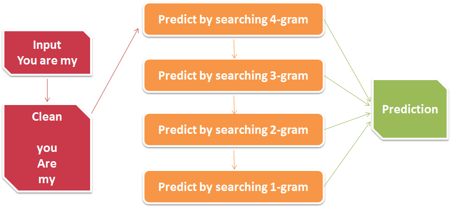

### User Guide

- After the app is lauched, you can see the following GUI.

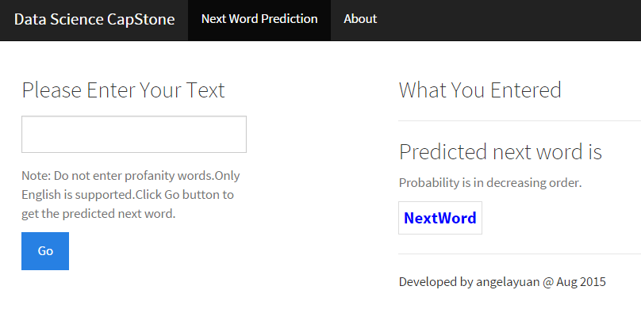

- Input please enter non-profanity English word in the input box at the left panel and click **Go** button to run the prediction algorithm.
- The program will used the last 1~3 words to predict the next word.

### User Guide

- Output You will see what you have entered and the top 10 words (if algorithm returns more than 10 words) will be listed in probability-decreasing order in a table at the right panel.
- More information Click “About” tab on the navigation bar.

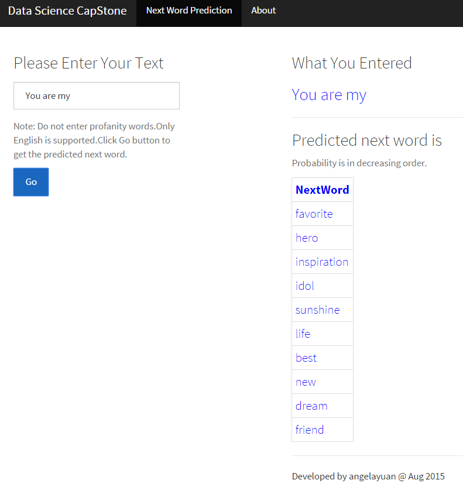